# Computing Assignment 5

Author

Andrew Kerr

# STAT 417: Survival Analysis Methods

## Computing Assignment 5: Due Friday 2-7-2025 at 11:59pm

You can browse through the document *Using R and R Studio for Survival Analysis* in the Week 5 module if you are unfamiliar with the R software. Additional R instructions/code for constructing the Kaplan-Meier estimator are provided at the end of the assignment.

### **1. Dryer Failure Times**

Suppose a sample of 7 dryers is selected and the times until failure (in years) were observed for a period of 10 years. The following times were recorded:

| Dryer | 1 | 2 | 3 | 4 | 5 | 6 | 7 |
| --- | --- | --- | --- | --- | --- | --- | --- |
| Time | 5 | 8 | 8 | 9 | 10+ | 10+ | 10+ |

where **“+”** indicates that the event time was right censored. Once you are in the R Studio environment, perform the following steps:

```r
# Load the survival package
library(survival)
library(tidyverse)
# Create vectors for event times and censoring status

time <- c(5,8,8,9,10,10,10)
censor <- c(1,1,1,1,0,0,0)

# Compute Kaplan-Meier estimates
KM.obj <- survfit(Surv(time,censor)~1, conf.type="none")
```

- Note: The conf.type=“none” option will suppress computation of confidence intervals for the survival probabilities. Otherwise, confidence intervals will show up on your plots.
- There are several options that can be specified within the survfit command above. Read the documentation for survfit in the help file for more information.
- Typing summary(KM.obj) will give you select quantities related to computing the Kaplan-Meier estimates, as well as standard errors of the estimated probabilities, and the confidence limits (if requested) for the true survival probabilities.

#### (a) Follow the code provided above to compute the Kaplan-Meier estimates of survival for each complete event time. Report the estimated survival probabilities for the complete event times.

```r
summary(KM.obj)
```

```
Call: survfit(formula = Surv(time, censor) ~ 1, conf.type = "none")

 time n.risk n.event survival std.err
    5      7       1    0.857   0.132
    8      6       2    0.571   0.187
    9      4       1    0.429   0.187
```

#### (b) Estimate the probability that a drier will last longer than 6 years.

$\hat{S}(6) = P(t>6) = 0.857$

#### (c) Estimate the median time until a drier fails.

$\hat{t}_{.5} = 9$

### **2. Ovarian Cancer Survival Analysis**

The data set `ovarian` is available for analysis in the `survival` package. Follow these preliminary steps:

- Read the description of the data set by typing `help(ovarian)`. Note that the observed event times  
  are contained in the variable `futime` (follow-up time measured in days from administration of treat-  
  ment until death), and the censoring status variable, fustat, takes value 0 for censored event times.  
  Construct the Kaplan-Meier estimator of the survival function for the time until death from ovarian  
  cancer.  
  `KM.obj <- survfit(Surv(futime,fustat)~1, data=ovarian, conf.typ="plain")`

Apply the `summary` and plot commands to **KM.obj** to answer the following questions:

```r
# Load and analyze ovarian cancer survival data
KM.obj <- survfit(Surv(futime, fustat)~1, data=ovarian, conf.type="plain")
summary(KM.obj)
```

```
Call: survfit(formula = Surv(futime, fustat) ~ 1, data = ovarian, conf.type = "plain")

 time n.risk n.event survival std.err lower 95% CI upper 95% CI
   59     26       1    0.962  0.0377        0.888        1.000
  115     25       1    0.923  0.0523        0.821        1.000
  156     24       1    0.885  0.0627        0.762        1.000
  268     23       1    0.846  0.0708        0.707        0.985
  329     22       1    0.808  0.0773        0.656        0.959
  353     21       1    0.769  0.0826        0.607        0.931
  365     20       1    0.731  0.0870        0.560        0.901
  431     17       1    0.688  0.0919        0.508        0.868
  464     15       1    0.642  0.0965        0.453        0.831
  475     14       1    0.596  0.0999        0.400        0.792
  563     12       1    0.546  0.1032        0.344        0.749
  638     11       1    0.497  0.1051        0.291        0.703
```

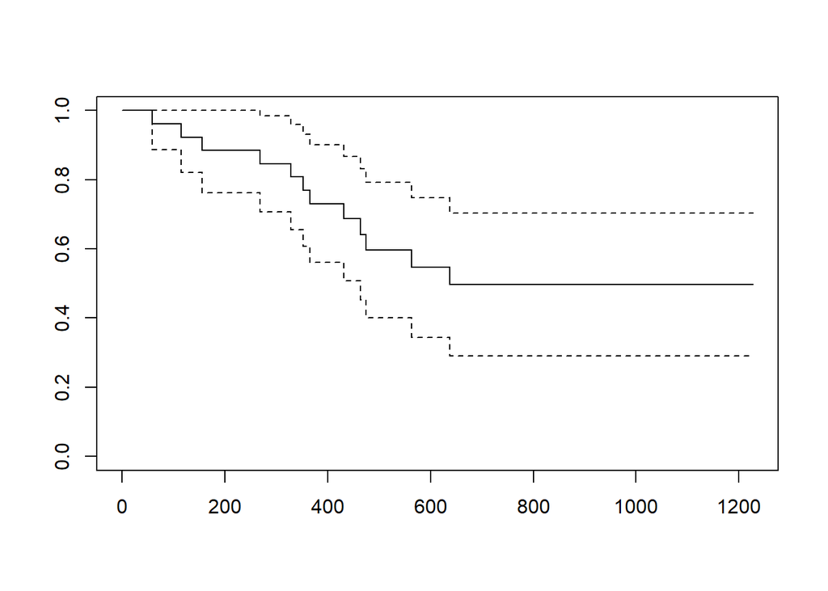

```r
plot(KM.obj)
```

#### (a) Estimate the proportion of ovarian cancer patients in the study who survived longer than 275 days after treatment.

$\hat{S}(275) = 0.846$

#### (b) Using the summary() command, find and report the 95% confidence interval for the probability that a randomly selected ovarian cancer patient survives longer than 275 days. Interpret the interval.

CI = (0.707, 0.985)

We are 95% confident that the true probability that a randomly selected ovarian cancer patient survives beyond 275 days is between .707 and .985.

#### (c) In the code for constructing the Kaplan-Meier estimator provided above, substitute conf.type = “plain” with conf.type = “log-log” to obtain the confidence intervals for the true survival probabilities based on the ln(− ln S(t)) approach. Find and report the 95% confidence interval for the probability that a randomly selected ovarian cancer patient survives longer than 275 days.

```r
KM.obj <- survfit(Surv(futime, fustat)~1, data=ovarian, conf.type="log-log")
summary(KM.obj)
```

```
Call: survfit(formula = Surv(futime, fustat) ~ 1, data = ovarian, conf.type = "log-log")

 time n.risk n.event survival std.err lower 95% CI upper 95% CI
   59     26       1    0.962  0.0377        0.757        0.994
  115     25       1    0.923  0.0523        0.726        0.980
  156     24       1    0.885  0.0627        0.684        0.961
  268     23       1    0.846  0.0708        0.640        0.939
  329     22       1    0.808  0.0773        0.598        0.915
  353     21       1    0.769  0.0826        0.557        0.889
  365     20       1    0.731  0.0870        0.517        0.862
  431     17       1    0.688  0.0919        0.471        0.830
  464     15       1    0.642  0.0965        0.422        0.796
  475     14       1    0.596  0.0999        0.377        0.760
  563     12       1    0.546  0.1032        0.328        0.721
  638     11       1    0.497  0.1051        0.282        0.679
```

CI = (0.640, 0.939).

#### (d) Estimate the probability that a randomly selected ovarian cancer patient survives beyond 563 days.

$\hat{S}(563) = 0.546$

#### (e) Note that the Kaplan-Meier curve does not reach 0 (nor does it come close). What does this imply about the treatment that was administered to the ovarian cancer patients?

This implies that roughly 50% (thats where the curve appears to end at) of patients are still alive at the end of the study, indicating that the treatment may be effective to the ovarian cancer patients.

### **3. Halibut Survival Study**

The data set Halibut located in the Canvas folder **Computing Assignment 5** contains measurements on  
294 Atlantic halibut caught for an experiment on size regulation. The variable **TIME** contains the survival  
time of halibut (time until death) in hours (measured from time of capture), and **CENSOR** is the censoring  
indicator taking value 1 for complete event times. Save this data file to the desk top.

- Import the Halibut data set into your R session.
- Construct the Kaplan-Meier estimator using the following syntax:

  `KM.obj <- survfit(Surv(TIME,CENSOR)~1, data=halibut, conf.type="log-log")`
- Apply the `summary` and `plot` commands to **KM.obj**, answer the following questions:

```r
# Load and analyze halibut survival data
halibut <- read_table(here::here("data", "Halibut.txt"))
KM.obj <- survfit(Surv(TIME, CENSOR)~1, data=halibut, conf.type="log-log")
summary(KM.obj)
```

```
Call: survfit(formula = Surv(TIME, CENSOR) ~ 1, data = halibut, conf.type = "log-log")

   time n.risk n.event survival std.err lower 95% CI upper 95% CI
    1.1    294       1   0.9966 0.00340      0.97610       0.9995
    1.2    293       1   0.9932 0.00479      0.97308       0.9983
    1.3    292       4   0.9796 0.00825      0.95514       0.9908
    1.4    288       3   0.9694 0.01005      0.94200       0.9840
    1.5    285       6   0.9490 0.01283      0.91680       0.9689
    1.6    279       1   0.9456 0.01323      0.91270       0.9663
    1.7    278       1   0.9422 0.01361      0.90863       0.9637
    1.9    277       1   0.9388 0.01398      0.90458       0.9610
    2.0    276       1   0.9354 0.01434      0.90055       0.9583
    2.5    275       1   0.9320 0.01468      0.89654       0.9556
    2.6    274       2   0.9252 0.01535      0.88858       0.9501
    2.7    272       1   0.9218 0.01566      0.88462       0.9473
    2.8    271       2   0.9150 0.01627      0.87675       0.9417
    2.9    269       1   0.9116 0.01656      0.87283       0.9389
    3.0    268       4   0.8980 0.01765      0.85730       0.9275
    3.1    264       3   0.8878 0.01841      0.84577       0.9189
    3.2    261       6   0.8673 0.01978      0.82297       0.9013
    3.3    255       1   0.8639 0.02000      0.81920       0.8983
    4.0    254       2   0.8571 0.02041      0.81168       0.8924
    4.2    252       2   0.8503 0.02081      0.80419       0.8864
    5.0    250       1   0.8469 0.02100      0.80046       0.8834
    5.2    249       1   0.8435 0.02119      0.79673       0.8804
    5.3    248       2   0.8367 0.02156      0.78929       0.8743
    7.8    246       1   0.8333 0.02174      0.78558       0.8713
    7.9    245       1   0.8299 0.02191      0.78188       0.8683
    8.0    244       1   0.8265 0.02208      0.77819       0.8653
    9.3    241       1   0.8231 0.02226      0.77446       0.8622
   10.4    239       4   0.8093 0.02293      0.75954       0.8498
   10.5    235       2   0.8024 0.02324      0.75212       0.8436
   10.6    233       1   0.7990 0.02340      0.74841       0.8405
   11.0    232       1   0.7955 0.02355      0.74471       0.8374
   11.1    231       1   0.7921 0.02370      0.74102       0.8342
   11.2    230       1   0.7887 0.02384      0.73733       0.8311
   11.6    229       1   0.7852 0.02398      0.73365       0.8280
   11.7    228       1   0.7818 0.02413      0.72997       0.8248
   11.8    227       3   0.7714 0.02453      0.71896       0.8154
   13.0    224       2   0.7646 0.02479      0.71165       0.8091
```

[output cut: 126 more lines]

```
  228.0     20       1   0.0765 0.01667      0.04811       0.1134
  240.0     19       1   0.0725 0.01627      0.04493       0.1087
  260.0     18       1   0.0685 0.01586      0.04177       0.1040
  264.0     17       1   0.0645 0.01543      0.03864       0.0992
  279.0     16       1   0.0604 0.01498      0.03555       0.0944
  353.0     15       2   0.0524 0.01402      0.02949       0.0847
  356.0     13       1   0.0483 0.01351      0.02652       0.0798
  377.0     12       1   0.0443 0.01297      0.02360       0.0748
  397.0     11       1   0.0403 0.01240      0.02074       0.0698
  404.0     10       1   0.0363 0.01180      0.01795       0.0648
  500.0      9       1   0.0322 0.01115      0.01522       0.0596
  713.0      8       1   0.0282 0.01046      0.01259       0.0544
  905.0      7       1   0.0242 0.00971      0.01006       0.0492
 1097.0      6       1   0.0201 0.00889      0.00765       0.0438
 1196.0      5       1   0.0161 0.00797      0.00540       0.0382
```

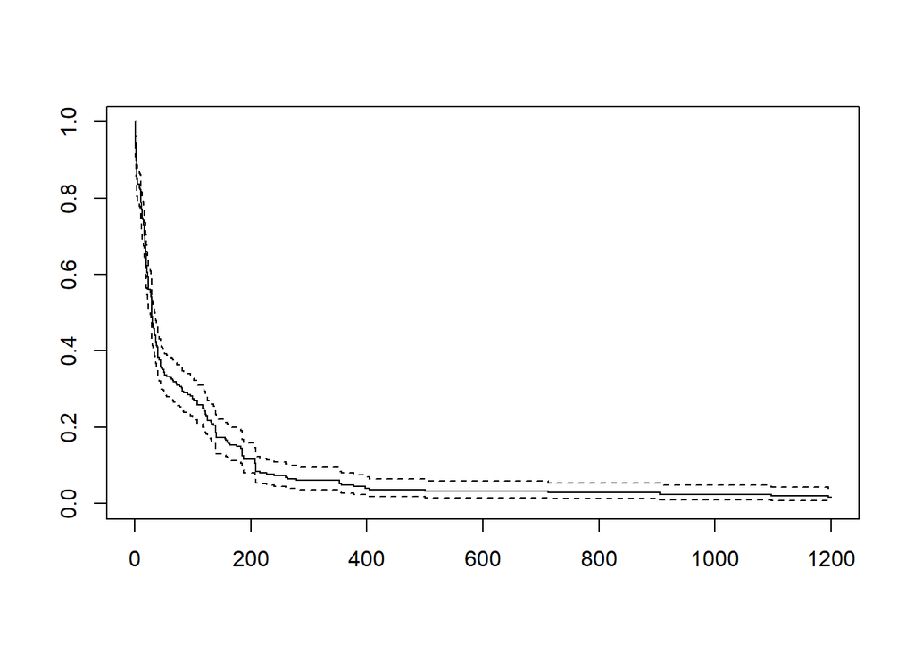

```r
plot(KM.obj)
```

#### (b) Estimate the proportion of halibut that survive beyond 20 hours.

$\hat{S}(20) = 0.6440$

**(c) Find and report the 95% confidence interval (standard form) for the probability that a randomly selected halibut will survive longer than 20 hours.**

CI = (0.58615, 0.6959)

#### (d) Use the print() command to find the estimated median halibut survival time, and the associated 95% confidence interval for the population median halibut survival time. Provide a brief interpretation of the interval.

```r
KM.obj
```

```
Call: survfit(formula = Surv(TIME, CENSOR) ~ 1, data = halibut, conf.type = "log-log")

       n events median 0.95LCL 0.95UCL
[1,] 294    273   29.8    26.5    35.8
```

CI = (26.5, 35.8)

## **Instructions for Constructing Kaplan-Meier Curves in R**

1. Open R Studio and load the `survival` package:

```r
library(survival)
```

2. If entering data manually, create vectors for event times and censoring status:

```r
TIME <- c(...)  # Observed event times
CENSOR <- c(...)  # Censoring indicators
KM.obj <- survfit(Surv(TIME, CENSOR)~1)
```

3. If loading a dataset:

```r
KM.obj <- survfit(Surv(TIME, CENSOR)~1, data=DATAFILE)
```

4. View summary statistics:

```r
summary(KM.obj)
```

5. Plot the Kaplan-Meier curve:

```r
plot(KM.obj)
```

6. To compare groups:

```r
KM.obj <- survfit(Surv(TIME, CENSOR)~GROUP, data=DATAFILE)
```